# Simulation

```r
library(tidyverse)
library(ggdist)
library(broom)
```

# Simulations

This document will walk through some methods for exploring models using Monte Carlo simulations. A Monte Carlo simulation uses repeated random sampling to understand the range of plausible outcomes from a random process. The specifics will change depending on the process we’re trying to model, but the basic steps are going to be:

1. Randomly generate some data
2. Estimate some parameter
3. Repeat steps 1 and 2 a bunch of times (1000 or more)
4. Describe the distribution of results

Monte Carlo simulations are useful for understanding how models behave because they give us a straightforward way to judge performance: we made the data, so we know the “true” values of our parameters, and so we can easily calculate things like the bias or variance of an estimator under a whole range of hypothetical scenarios.

## Quick note on (Pseudo) - Randomness

Every “random” number generating process in R - and really in practically all computing - is actually pseudo-random. Once you have an initial state or seed, every subsequent draw is deterministic and you can predict it perfectly if you know the algorithm being used. (See [here](https://rpubs.com/aaronsc32/linear-congruential-generator-r) for a nice example of one such algorithm). Pseudo-randomness is partly a matter of necessity ([true RNG is hard](https://lloydm.net/Demos/prng.html)) but its ultimately beneficial to researchers because it means we can easily replicate ostensibly random processes as long as we keep track of the initial state.

All of this is a round about way of saying: any time you are using a random process in R that you want to replicate, you need to use the `set.seed` command first so that you can ensure your results are replicable.

You also want to pay attention to *where* you set the seed. Note that this produces all “d”s:

```r
for(i in 1:5){
  set.seed(1999)
  print(sample(letters, size=1))
}
```

```
[1] "d"
[1] "d"
[1] "d"
[1] "d"
[1] "d"
```

But this produces different letters. Why?

```r
set.seed(1999)
for(i in 1:5){
  print(sample(letters, size=1))
}
```

```
[1] "d"
[1] "d"
[1] "r"
[1] "r"
[1] "v"
```

# Using Randomness to test assumptions

We’ll start with a basic example of generating the data for a linear model with a single parameter. Remember that the linear regression model assumes a data generating process that looks like this:

$$y_i = \beta_0 + x_i\beta_1 + \epsilon_i$$

Where $y$ is a dependent variable, $x$ is an independent variable, $\epsilon$ is some random error and $\beta_0$ and $\beta_1$ are the intercept and slope coefficients, respectively. We can simulate this data generation process with a few lines of code:

```r
set.seed(2000)
N <-  500 # the sample size
X <- rnorm(N, mean=0, sd=1) # an independent variable
e <- rnorm(N, mean=0, sd=1) # the error term
beta_0 <- 1
beta_1 <- 0.1
Y <- beta_0 + X * beta_1 + e # the dependent variable
```

How well does the linear regression model perform when trying to estimate those coefficient values?

```r
lm(Y ~ X)
```

```
Call:
lm(formula = Y ~ X)

Coefficients:
(Intercept)            X
      1.067        0.140
```

Pretty close! There’s a small difference between our actual parameters and the ones inferred by our model. This is probably the result of random sampling error.

Now lets run a bunch of simulations and see if our estimates are close to the correct answer on average:

We’ll use 1,000 iterations for the simulations in this document, but in general more iterations is usually better. The only real downside is that more iterations takes more time and more computing power

```r
set.seed(2000)
iterations<-1000
N <-  500 # the sample size
beta_0 <- 1  # the y intercept
beta_1<- 0.1 # the effect of X on Y
coefs<-list()

for(i in 1:iterations){
  X <- rnorm(N, mean=0, sd=1) # an independent variable
  e <- rnorm(N, mean=0, sd=1) # the error term
  Y <- beta_0 + X * beta_1 + e # the dependent variable
  mod<- lm(Y ~ X)
  coefs[[i]]<- tidy(mod, conf.int = TRUE) # make a data frame from the model
}



# combine results from all iterations
coefmat<-bind_rows(coefs, .id='iteration')
```

`coefmat` contains the results of 1,000 iterations of the same simulation we did in the previous section:

```r
coefmat|>
  slice_head(n=5)
```

| iteration | term | estimate | std.error | statistic | p.value | conf.low | conf.high |
| --- | --- | --- | --- | --- | --- | --- | --- |
| 1 | (Intercept) | 1.0668805 | 0.04574413 | 23.322786 | 7.235190e-82 | 0.97700524 | 1.1567558 |
| 1 | X | 0.1400340 | 0.04597329 | 3.045986 | 2.442130e-03 | 0.04970849 | 0.2303595 |
| 2 | (Intercept) | 1.0190483 | 0.04384317 | 23.243034 | 1.763088e-81 | 0.93290791 | 1.1051887 |
| 2 | X | 0.1399356 | 0.04587326 | 3.050484 | 2.406518e-03 | 0.04980665 | 0.2300646 |
| 3 | (Intercept) | 0.9766216 | 0.04504791 | 21.679621 | 6.847828e-74 | 0.88811424 | 1.0651290 |

Now can summarize our estimates of $\beta_0$ and $\beta_1$ across all simulations:

```r
coefmat|>
  group_by(term)|>
  summarise(mean = mean(estimate),
            median = median(estimate),
            sd = sd(estimate),
            `2.5th percentile` = quantile(estimate, .025),
            `97.5th percentile` = quantile(estimate, .975)
            )
```

| term | mean | median | sd | 2.5th percentile | 97.5th percentile |
| --- | --- | --- | --- | --- | --- |
| (Intercept) | 0.99912789 | 0.99701088 | 0.04498426 | 0.91570888 | 1.0950374 |
| X | 0.09914806 | 0.09982104 | 0.04634626 | 0.01038814 | 0.1901008 |

We can use the `ggdist` package to visualize the distribution of estimates for $\beta_1$

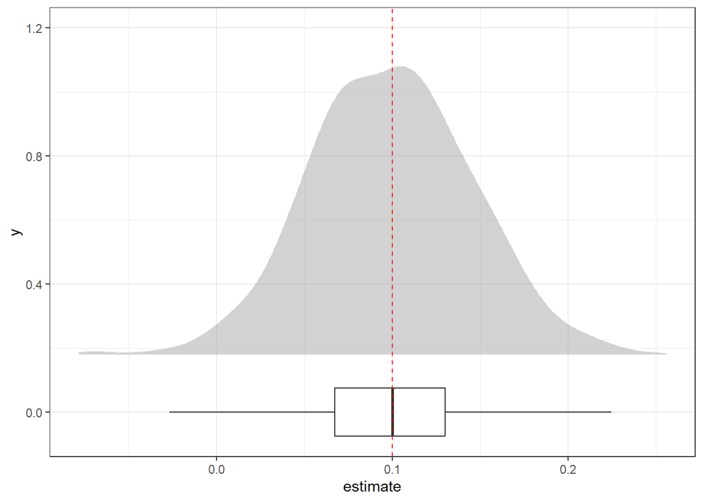

```r
coefmat |>
  filter(term == "X") |>
  ggplot(aes(x = estimate)) +
  stat_halfeye(alpha = .5,width = .6,.width = 0,justification = -.2) +
  geom_boxplot(width = .15, outlier.shape = NA) +
  theme_bw()+
  geom_vline(xintercept=beta_1, col='red', lty=2)
```

## Question 1

How often would we expect to encounter a Type II error (incorrectly failing to reject the null hypotheses) at this sample size/effect size?

Use `coefmat` to calculate the proportion of simulations where we would **fail to reject the null hypothesis at the p<.05 level.**

```r
# Your code here
```

## Question 2

Using the results from the previous simulation, estimate how often a 95% confidence interval for $\beta_1$ does not contain the correct estimate (if you think about the definition of a confidence interval, you should be able to predict your results here before you run anything)

```r
# Your code here

coefmat|>
  filter(term == "X")|>
  summarise(outside_ci = mean(conf.low > 0.1  | conf.high < 0.1))
```

| outside_ci |
| --- |
| 0.06 |

## Question 3

Using the loop above as a template, create a new simulation for a model where X has **no effect on the expected value of Y**. How often would we get a Type I error (incorrectly rejecting the null hypothesis) at the .05 level?

(we’ll keep the sample size at 500 and the number of iterations at 1000)

```r
# your code here

# keeping iterations, random seed and sample size the same:
set.seed(999)
iterations<-1000
N <-  500
```

# Comparing multiple conditions

In many cases, we’ll want to compare results from a model under a wide range of different conditions so we can explore things like the relationship between sample size and Type II error rates. We can use a nested loop to run simulations across a range of different parameter values.

For instance, here’s how we would run the same simulation at a sample size of 50, 500, and 5000:

```r
set.seed(999)
sample_size<-c(50, 500, 5000)
result_frame<-tibble()
for(N in sample_size){
  iterations<-1000

  beta_0 <- 1
  beta_1 <- 0.05
  coefs<-list()
  # The simulation
  for (i in 1:iterations) {
    X <- rnorm(N, mean = 0, sd = 1) # an independent variable
    e <- rnorm(N, mean = 0, sd = 1) # the error term
    Y <- beta_0 + X * beta_1 + e # the dependent variable
    mod <- lm(Y ~ X)
    coefs[[i]] <- tidy(mod, conf.int = TRUE, conf.level = .95)
  }

  # combine results
  coefmat<-bind_rows(coefs, .id='iteration')
  # add a variable to indicate the condition applied for this loop
  coefmat$sample_size <- N
  # add the rows to a data frame
  result_frame<-bind_rows(result_frame, coefmat)

}

# how often do we have a type II error at N=50, 500, or 5000?
result_frame|>
  filter(term == "X")|>
  group_by(sample_size)|>
  summarise(`proportion p>=.05` = mean(p.value>=.05))
```

| sample_size | proportion p>=.05 |
| --- | --- |
| 50 | 0.922 |
| 500 | 0.783 |
| 5000 | 0.058 |

What if we wanted to look at our Type II error rates when N=50 while varying the effect size for $\beta_1$?

To do this, we just need to change a few lines of our loop:

```r
set.seed(999)
N <- 50                  # set a fixed value for N
betas <- c(0.05, 0.1, 1) # Make a vector of betas

result_frame<-tibble()
for(b in betas){
  iterations<-1000
  beta_0 <- 1
  beta_1 <- b
  coefs<-list()
  for (i in 1:iterations) {
    X <- rnorm(N, mean = 0, sd = 1)
    e <- rnorm(N, mean = 0, sd = 1)
    Y <- beta_0 + X * beta_1 + e
    mod <- lm(Y ~ X)
    coefs[[i]] <- tidy(mod, conf.int = TRUE, conf.level = .95)
  }

  coefmat<-bind_rows(coefs, .id='iteration')

  coefmat$beta_1 <- b # add a column to indicate the beta value in this simulation

  result_frame<-bind_rows(result_frame, coefmat)

}
```

And now we can estimate the type II error rate across these simulations:

```r
# how often do we have a type II error at b = 0.05, 0.10, or 1 and N = 50?
result_frame|>
  filter(term == "X")|>
  group_by(beta_1)|>
  summarise(`proportion p>=.05` = mean(p.value>=.05))
```

| beta_1 | proportion p>=.05 |
| --- | --- |
| 0.05 | 0.922 |
| 0.10 | 0.891 |
| 1.00 | 0.000 |

### Omitted variable bias

We can use the same general approach to explore the effects of omitted variable bias. Omitted variable bias happens when there are variables correlated with predictors AND with the outcome of interest that are left out of the model. The code below uses `mvrnorm` to create two correlated random variables that both influence Y, but then estimates a model that only includes the first of those correlated predictor variables.

```r
betas <- c(1, 3) # Make a vector of betas
corr_x <- .8
intercept <- 1
Sigma <- matrix(c(1, corr_x, corr_x, 1), ncol=2)
X <- MASS::mvrnorm(N, mu=c(0, 0), Sigma=Sigma)
e <- rnorm(N, 0 , sd=1) # the variance of the error term
Y <- intercept  + X %*% betas + e
mod <- lm(Y ~ X[,1]) # Omitting X[,2] from the regression model
coefs<-tidy(mod, conf.int = TRUE, conf.level = .95)
```

```r
coefs
```

| term | estimate | std.error | statistic | p.value | conf.low | conf.high |
| --- | --- | --- | --- | --- | --- | --- |
| (Intercept) | 0.6432119 | 0.2952342 | 2.178649 | 3.429954e-02 | 0.04960368 | 1.236820 |
| X[, 1] | 3.4707216 | 0.3147260 | 11.027758 | 9.349719e-15 | 2.83792264 | 4.103521 |

Now we can see how our model performs when the omitted variables have a negative correlation, no correlation, or a positive correlation with the other predictor:

```r
iterations<- 500
betas <- c(1, 3) # Make a vector of betas
intercept <- 1
correlations <- c(-.8, 0, .8)
results<-tibble()

for(ci in correlations) {
  coefs<-list()
  for (i in 1:iterations) {
    Sigma <- matrix(c(1, ci, ci, 1), ncol = 2)
    X <- MASS::mvrnorm(N, mu = c(0, 0), Sigma = Sigma)
    e <- rnorm(N, 0 , sd = 1) # the variance of the error term
    Y <- intercept  + X %*% betas + e
    mod <- lm(Y ~ X[, 1]) # Omitting X[,2] from the regression model
    coefs[[i]] <- tidy(mod, conf.int = TRUE, conf.level = .95)
  }
  coefmat<-bind_rows(coefs, .id='iteration')
  coefmat$correlation<-paste("r = ", ci)

  results<-bind_rows(results, coefmat)

}
```

How much do our estimates differ from the correct answer? And how does the relationship between these variables change the results?

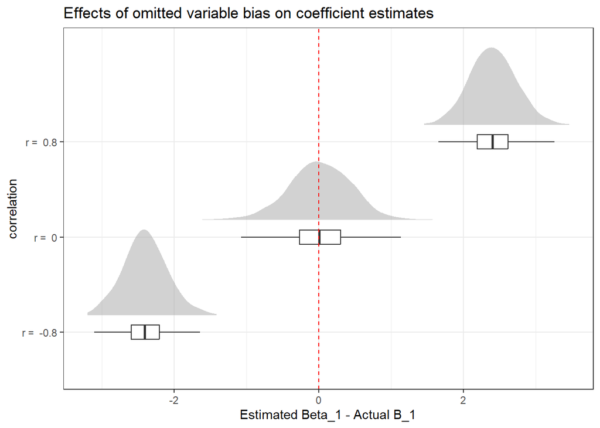

```r
results |>
  filter(term == "X[, 1]") |>
  # calculate the bias (estimated beta_1 minus the value set in the data generating function)
  mutate(bias = estimate - 1)|>
  ggplot(aes(x = bias, y = correlation, )) +
  stat_halfeye(
    alpha = .5,
    width = .6,
    .width = 0,
    justification = -.2
  ) +
  geom_boxplot(width = .15, outlier.shape = NA) +
  theme_bw() +
  geom_vline(xintercept = 0,
             lty = 2,
             col = 'red') +
  xlab("Estimated Beta_1 - Actual B_1") +
  ggtitle("Effects of omitted variable bias on coefficient estimates")
```

## Question 4

Rewrite the code above so that the effect of $\beta_2$ (the omitted variable) is negative instead of positive. How does this impact your results?

```r
# Code
```

# Extra code: Using a simulation function

Writing multiple nested loops can get a little unwieldy, so we can simplify some of the code here by creating functions to handle the repetitive parts of this process.

The `runSim` function will take a data generating function `func` as an argument along with a data frame containing the arguments to use in each run of the simulation. The `aggregateResults` function will give us some summary statistics for the coefficient estimates across each run:

```r
# Runs the simulation across different parameter values  (replaces the outer loop in the prior examples)
runSim<-function(func, parmlist, iterations=1000, seed=NULL){
  if(!is.null(seed)){
    set.seed(seed)
  }
  all_results<-tibble()
  for(i in 1:length(parmlist)){
    result<-replicate(iterations, do.call(func, parmlist[[i]]), simplify=FALSE)|>
      bind_rows()
    result$condition<-i
    all_results<-bind_rows(all_results, result)

  }
  if(!is.null(names(parmlist))){
    all_results$condition <- factor(all_results$condition, labels=names(parmlist))
  }

  return(all_results)
}

# Function to get aggregate stats from model results
aggregateResults<-function(results){
  agged <- results |>
    group_by(condition, term) |>
    summarise(
      mean = mean(estimate),
      median = median(estimate),
      sd = sd(estimate),
      `2.5th percentile` = quantile(estimate, .025),
      `97.5th percentile` = quantile(estimate, .975),
      `proportion p>=.05` = mean(p.value >= .05)
    )
  return(agged)
}
```

### Increasing N

Here’s an example of doing the same simulation we ran above using the `runSim` function. Instead of generating a nested loop, we just set up a list-of-lists containing the arguments that we want to pass to `genFunc`.

```r
# a data generation function with defaults (replaces the inner loop in the prior examples)
genFunc <- function(N, betas){
  X = cbind(rnorm(N, 0, 1))
  intercept = 1
  e = rnorm(N, 0 , 1)
  Y <- intercept  + X %*% betas + e
  mod <- lm(Y ~ X)
  coefs<-tidy(mod, conf.int = TRUE, conf.level = .95)
  return(coefs)

}

plist<-list(
  'N=50,   beta_1=0.05' =  list(betas=0.05, N=50),
  'N=100,  beta_1=0.05'=   list(betas=0.05, N=100),
  'N=1000, beta_1=0.05' =  list(betas=0.05, N=1000)
)
```

Then we pass `genFunc` and `plist` as arguments to `runSim`

```r
results<- runSim(func=genFunc,
                 parmlist = plist,
                 seed = 999
)
```

Now, we can summarize the results for each condition:

```r
# summarize the results
aggregateResults(results)|>
  filter(term=="X")
```

| condition | term | mean | median | sd | 2.5th percentile | 97.5th percentile | proportion p>=.05 |
| --- | --- | --- | --- | --- | --- | --- | --- |
| N=50, beta_1=0.05 | X | 0.05754167 | 0.05485753 | 0.14661228 | -0.23437526 | 0.3472896 | 0.922 |
| N=100, beta_1=0.05 | X | 0.04490034 | 0.04490392 | 0.10264734 | -0.16453195 | 0.2355700 | 0.925 |
| N=1000, beta_1=0.05 | X | 0.04876857 | 0.04912001 | 0.03245521 | -0.01280081 | 0.1101104 | 0.650 |

What if we try different values for `beta_1` while using a sample size of 50?

```r
plist<-list(
  'N=50, beta_1=0.05' = list(betas= .05, N=50),
  'N=50, beta_1=0.1' =  list(betas= 0.1, N=50),
  'N=50, beta_1=0.5' =  list(betas= 0.5, N=50)
)

results<- runSim(func=genFunc,
           parmlist = plist,
           seed = 999
)

# summarize the results
aggregateResults(results)|>
  filter(term=="X")
```

| condition | term | mean | median | sd | 2.5th percentile | 97.5th percentile | proportion p>=.05 |
| --- | --- | --- | --- | --- | --- | --- | --- |
| N=50, beta_1=0.05 | X | 0.05754167 | 0.05485753 | 0.1466123 | -0.2343753 | 0.3472896 | 0.922 |
| N=50, beta_1=0.1 | X | 0.10143920 | 0.09350106 | 0.1444887 | -0.1881363 | 0.3926948 | 0.891 |
| N=50, beta_1=0.5 | X | 0.50518117 | 0.50993189 | 0.1411302 | 0.2255388 | 0.7910497 | 0.075 |

### More variance in the error term

What happens to the estimates if you increase the variance in the error term `e`? Start by modifying `genFunc` to allow us to set the standard deviation of the error term as a function argument (note, we can also include optional arguments to change the sample size and beta coefficients here, but we set them at some reasonable defaults)

```r
genFunc <- function(e_sd, N=1000, betas=1){
  X = cbind(rnorm(N, 0, 1))
  intercept = 1
  e = rnorm(N, 0 , sd=e_sd) # the variance of the error term
  Y <- intercept  + X %*% betas + e
  mod <- lm(Y ~ X)
  coefs<-tidy(mod, conf.int = TRUE, conf.level = .95)
  return(coefs)

}
```

Then create a nested list containing the set of parameter values you want to pass along to `genFunc` and pass them to the `runSim` argument.

```r
plist<-list(
  'sd(e) = 1' =   list(e_sd=1),
  'sd(e) = 10' =  list(e_sd=10),
  'sd(e) = 20' =  list(e_sd=20)
)


results<- runSim(func=genFunc,
           parmlist = plist,
           seed = 999
)

# summarize the results
aggregateResults(results)|>
  # we're really only interested in b_1 here, so we'll filter out the intercept:
  filter(term=="X")
```

| condition | term | mean | median | sd | 2.5th percentile | 97.5th percentile | proportion p>=.05 |
| --- | --- | --- | --- | --- | --- | --- | --- |
| sd(e) = 1 | X | 0.9989941 | 0.9995549 | 0.03186807 | 0.9387356 | 1.059337 | 0.000 |
| sd(e) = 10 | X | 0.9880112 | 0.9866158 | 0.32117683 | 0.3722518 | 1.596747 | 0.136 |
| sd(e) = 20 | X | 0.9969554 | 0.9963297 | 0.60998056 | -0.1605596 | 2.279022 | 0.667 |

Now plot the results

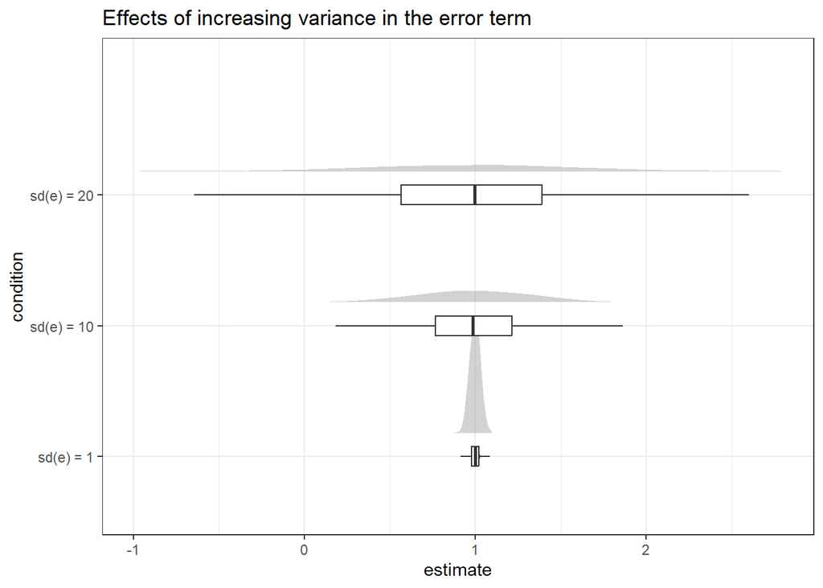

```r
results |>
  filter(term == "X")|>
  ggplot(aes(x = estimate, y = condition)) +
  stat_halfeye(
    alpha = .5,
    width = .6,
    .width = 0,
    justification = -.2
  ) +
  geom_boxplot(width = .15, outlier.shape = NA) +
  theme_bw() +
  ggtitle("Effects of increasing variance in the error term")
```